# LLM embeddings vs. traditional sentiment on earnings calls

A comparative backtest on a 100-ticker Nasdaq-100 universe

Author

FINM 33200 final project

Published

May 23, 2026

## 1. Motivation

Earnings calls are the densest periodic information event in equity markets. A two-hour call typically contains prepared remarks from management, Q&A with sell-side analysts, and forward guidance — material that moves prices on the day and continues to be re-priced through the subsequent quarter as investors digest the language.

This project asks a narrow version of a long-running empirical-asset-pricing question: **do modern LLM embeddings of earnings-call transcripts carry cross-sectional return information beyond what a traditional lexicon and the standard non-text factors already provide?** The recent S&P Global Market Intelligence whitepaper (Ao and Zhao, 2025) tackles the same question at Russell-3000 scale with a fine-tuned LLM and reports the LLM signal roughly doubles a Loughran-McDonald lexicon baseline. We replicate the *shape* of that question on a smaller, fully reproducible setting:

- **Universe:** 100 Nasdaq-100 tickers drawn from the current index membership. Fixed list, no point-in-time membership.
- **Embeddings:** off-the-shelf OpenAI `text-embedding-3-small`, no fine-tuning.
- **Backtest machinery:** identical across all five signals — monthly rebalance, top-quintile / bottom-quintile equal-weighted long-short (top and bottom 20 % of valid signal values each month), 21-trading-day holding period, no transaction costs.

The project is **comparative**, not absolute. Universe, holding period, ranking rule, and benchmark are identical across signals; what differs is the signal value used to rank stocks at each month-end. Statements made below about a signal’s performance are statements about its rank position relative to the four others on this universe, on this window, under this spec — not claims about a deployable trading strategy.

## 2. The five signals

Five cross-sectional long-short signals run on identical backtest machinery. What differs is only the signal value used to rank stocks at each month-end.

| # | Signal | Family | What it measures |
| --- | --- | --- | --- |
| 1 | **Anchor cosine on Δ sentiment** | LLM, hand-anchored | Projection of the call vector onto a 10-sentence positive-minus-negative direction, quarter-over-quarter change |
| 2 | **Ridge + PCA on Δ call vectors** | LLM, learned | RidgeCV on PCA(50) of the 1,536-D embedding delta + `days_since_earnings`, supervised on 21-day forward returns |
| 3 | **Loughran-McDonald Δ net positivity** | Lexicon | Bag-of-words match against the LM Positive / Negative dictionaries, net-positivity Δ between consecutive calls |
| 4 | **Price momentum 12-1** | Non-text factor | Standard cross-sectional momentum, last 12 months excluding the most recent |
| 5 | **Analyst revisions in Δ blended-forward net income** | Non-text factor | 21-business-day percentage change in Bloomberg’s `BEst Net Income` 1BF (blended-forward 12-month) consensus |

Signals (1)–(3) are computed per earnings call and carried forward at month-end until the next call refreshes them. Signals (4)–(5) refresh independently every month from prices and Bloomberg consensus.

The two LLM signals (1 and 2) are **both first-class methodological tests**, not a “cheap baseline plus the real one”. Strategy 1 takes the embedding and forces all interpretive burden onto ten hand-written anchor sentences; Strategy 2 lets supervised learning identify return-relevant directions in the embedding delta. They answer different questions — *“is hand-written semantic distance informative?”* vs *“is there a learnable signal in the raw call-to-call shift?”* — and the comparison between them is itself part of the result. Strategies 3–5 are the three benchmarks the LLM signals have to beat to claim incremental information over the lexicon and the standard cross-sectional factors.

### 2.1 Anchor cosine on Δ sentiment (LLM, hand-anchored)

We hand-write five “positive” sentences (e.g. *“We had a record-breaking quarter with strong revenue growth”*) and five “negative” sentences (*“We are lowering our outlook due to weak demand and macro headwinds”*). Each anchor list is embedded and pooled to a single L2-normalised vector $a_{\text{pos}}$ / $a_{\text{neg}}$. For every earnings call $(i, t)$ the per-call sentiment-diff score is

$$s_{i,t} = \cos(v_{i,t}, a_{\text{pos}}) - \cos(v_{i,t}, a_{\text{neg}})$$

and the ranking signal (stored in the panel as `sig_anchor`) is its call-to-call change $\Delta s_{i,t} = s_{i,t} - s_{i,t-1}$, where $v_{i,t}$ is the per-call vector (§3) and $t-1$ is the same ticker’s previous call. Working in Δ removes a company-fixed-effect direction: some industries naturally talk more about R&D, some more about logistics, and the *level* of cosine is contaminated by that; the *change* isolates the new language of the quarter.

**Why this method.** It is the cheapest possible way to project a 1,536-D embedding onto an interpretable direction. No labels, no training, no tuning — all of the modelling load sits in the choice of the ten anchor sentences. That is also its weakness: a different ten anchors would give a different score, and we have not done a sensitivity sweep on the choice (listed in §6).

### 2.2 Ridge + PCA on Δ call vectors (LLM, learned)

Instead of projecting onto a hand-written direction, we let supervised learning pick the directions. Per call, the feature vector is the 1,536-D Δ-call vector concatenated with $\tau_{i,t}$ = calendar days since the prior call (`days_since_earnings` in the panel, a freshness control). A 7-year training window (2012-2018) feeds an expanding-window pipeline of `PCA(n_components=50)` → `StandardScaler` → `RidgeCV` over $\alpha \in \{0.01, 0.1, 1, 10, 100, 1000\}$ with `TimeSeriesSplit(5)`. PCA is necessary: with the raw 1,537-D feature vector, RidgeCV saturated at $\alpha = 1000$ in every fold and the resulting long-short Sharpe was ~0.05; collapsing the embedding delta to 50 PCs first gives ridge something it can actually regularise. The frozen model from year $Y-1$ scores all calls in year $Y$; the predicted 21-day forward return is stored as `sig_ridge`.

**Why this method.** It is the strict cross-validation answer to *“is there a return-predictive direction in the raw embedding delta that anchor cosine can’t see?”* With PCA pre-reduction the model survives cross-validation and produces an out-of-sample Sharpe well above the LM lexicon’s.

### 2.3 Loughran-McDonald Δ net positivity (Lexicon)

The classical text-NLP baseline. We tokenise the full transcript and count tokens in the LM Positive list ($A_{i,t}$) and the LM Negative list ($B_{i,t}$). The per-call LM net-positivity score is

$$L_{i,t} = \frac{A_{i,t} - B_{i,t}}{A_{i,t} + B_{i,t}}$$

and the ranking signal (panel column `sig_lm`) is its call-to-call change $\Delta L_{i,t} = L_{i,t} - L_{i,t-1}$.

Only Positive and Negative are used. The other LM categories (Uncertainty, Litigious, Strong/Weak Modal, Constraining) are not standard ingredients of net positivity and are excluded by design. Calls with zero LM-listed words are dropped.

**Why this method.** Loughran and McDonald (2011) is the canonical finance-domain lexicon and the S&P whitepaper’s own benchmark. Including it here lets us answer “does an LLM-embedding signal beat the lexicon-counting signal on this universe?” — the same comparative shape as S&P’s headline.

### 2.4 Price momentum 12-1 (Non-text factor)

Standard cross-sectional momentum. At month-end $m$ the signal is the cumulative simple total return from 12 months ago to one month ago,

$$M_{i,m} = \prod_{k=2}^{12}(1 + r_{i,m-k}) - 1$$

(panel column `sig_mom`). The most recent month is skipped to dodge the well-known one-month reversal effect.

**Why this method.** Jegadeesh and Titman (1993). It is the equity factor every quant practitioner already has. If a text-derived signal cannot beat 12-1 momentum, it is not adding much.

### 2.5 Analyst revisions in Δ blended-forward net income (Non-text factor)

Let $B_{i,m}$ denote the Bloomberg consensus `BEst Net Income` for ticker $i$ at month-end $m$. At month-end $m$, the ranking signal (panel column `sig_rev`) is the 21-business-day percentage change in that consensus, normalised by its absolute prior value:

$$R_{i,m} = \frac{B_{i,m} - B_{i,m-21}}{\left| B_{i,m-21} \right|}$$

The Bloomberg field is `BEST_NET_INCOME`, which under Bloomberg’s default `1BF` (“1-blended-forward”) methodology is **not raw FY1 net income** — it is a days-weighted blend of FY1 and FY2 (or FY2 and FY3 once the FY1 reporting date has passed):

$$B = \tfrac{d}{D}\cdot\mathrm{FY1} + \left(1 - \tfrac{d}{D}\right)\cdot\mathrm{FY2}$$

where $d$ is the number of trading days until the next fiscal year-end and $D$ is the trading days in a year. This is the definition Bloomberg documents directly on the `Info` sheet of the company-data workbook we use to pull the consensus.

**Why this method.** Estimate revisions are the second standard non-text factor (after price momentum) that any equity strategy is built against. The 21-business-day window aligns the revision horizon with the forward-return horizon used everywhere else in the project.

## 3. Data

### 3.1 Universe

100 Nasdaq tickers drawn from current Nasdaq-100 membership. The list is **fixed across the entire backtest period** — no point-in-time index reconstitution. The transcript-derived signals (anchor, ridge, LM) cover the 100 names; the price- and Bloomberg-derived signals (momentum, revisions) cover one additional name where coverage allows.

**Survivorship bias.** Names that delisted, were acquired, or fell out of the index do not appear. Bias should largely cancel in the *relative* comparison across signals (they all see substantially the same universe), but symmetry of bias across signals is an assumption, not a verified property, and is named in §6.

### 3.2 Transcripts — what we pull and what we do with them

Full earnings-call transcripts are pulled from **WRDS Capital IQ** at the **component level**: one row per speech act, tagged with a section type (presentation operator message, presenter speech, Q&A operator message, question, answer, unknown Q&A message) and a speaker-type code for operator / management / analyst.

Each call is then **cleaned and section-parsed**, then rolled up to a single per-call `full_text` view. The cleaning step makes a handful of explicit assumptions that need calling out, since they are deliberate choices, not transparent defaults:

- **Unicode and whitespace normalisation.** NFKC normalisation, collapsing runs of spaces and stripping fancy quotes / dashes — the only formatting transformation applied. No lowercasing, no stopword removal: the embedding model was trained on natural English text, so aggressive cleaning would push the input out of its training distribution.
- **Safe-harbor language removed only when conservative.** Forward-looking-statement disclaimers (*“Actual results may differ materially…”*) are flagged via a strong/supporting pattern split. A short component (≤350 words) that contains a strong pattern is dropped. A medium component (≤700 words) is dropped only if it has two strong hits *and* a supporting hit. A long component that mixes a disclaimer with substantive remarks is **kept** and flagged for review — we do not want to delete an entire prepared-remarks block just because it opens with a boilerplate disclaimer.
- **Operator boilerplate removed where it is purely procedural.** Patterns like *“welcome to the call”*, *“press star to ask a question”*, *“you may disconnect”* are removed. Structural operator messages (*“first question…”*, *“next question…”*, *“turn the call over to…”*) are retained because they carry section structure.
- **Blank components dropped.** No other components are removed.
- **Per-call view = concatenation of all retained components in order.** Each component is prefixed with `[section_type] speaker_name:` so the embedding model can see who is talking. Multiple views are produced (full transcript, presentation only, Q&A only, management-answers only); this project uses the **full transcript view** end-to-end. Q&A-only is listed in §6 as future work.

### 3.3 Embeddings — chunking and per-call pooling

Each cleaned per-call transcript is **chunked to fit the embedding model’s context window**:

1. Tokenise with `tiktoken` using the `text-embedding-3-small` encoder.
2. Walk the token sequence and start a new chunk whenever the running total exceeds **~6,000 tokens**.
3. If any single transcript component is longer than **7,500 tokens**, hard-split it before chunking.

The 6,000-token target sits comfortably below the model’s hard limit of 8,192 tokens — chosen with a margin so that no chunk ever truncates. The 7,500 hard-split threshold handles the rare case where a single uninterrupted management speech blows past one chunk’s worth on its own; it guarantees no single component is split across more than one chunk unnecessarily.

Each chunk is sent to **OpenAI `text-embedding-3-small`** (1,536-D, near-unit-norm). The **per-call vector** is the **`n_chars`-weighted mean** of the chunk embeddings, re-normalised to unit length. Character-weighting (rather than uniform) means longer prepared sections naturally dominate the per-call representation in proportion to how much they say — the same property a human reader would apply. The per-call vector is what enters every LLM-based signal (anchor cosine and ridge); the per-call $\Delta v_{i,t} = v_{i,t} - v_{i,t-1}$ enters as the supervised feature.

### 3.4 Prices and analyst estimates

Daily prices and the Bloomberg consensus `BEst Net Income` come from **Bloomberg Terminal exports**, pulled manually into a workbook and parsed into the analysis pipeline. Prices are converted to a monthly panel (last business day of month) and to 21-trading-day forward returns aligned to each earnings-call event date for the ridge model. The `BEst Net Income` field is the Bloomberg `1BF` blended-forward measure described in §2.5.

### 3.5 Loughran-McDonald dictionary

The Loughran-McDonald master dictionary — 86,554 words with seven finance-specific category flags. Only Positive and Negative are used for the LM baseline, following standard practice.

## 4. Headline results

### 4.1 Return / risk metrics, full history per strategy

Each strategy uses its own full history, so `Months` differs across rows. Ridge + PCA starts in Feb 2019 (it needs the 2012-2018 training warm-up — see §2.2); the other LLM and lexicon signals start in 2006-2008; momentum and revisions go back to the early 2000s. For apples-to-apples cumulative-return charts on a common window, see §4.4; for an apples-to-apples *table* on the common post-2018 window, see §5.2.

Table 1

|  | Strategy | Ann. return | Ann. vol | Sharpe | Max DD | Hit rate | IR vs. bench | Months |
| --- | --- | --- | --- | --- | --- | --- | --- | --- |
| 0 | 1. Anchor cosine (LLM) | +3.9% | +11.0% | +0.35 | -23.2% | +58.3% | -0.70 | 230 |
| 1 | 2. Ridge + PCA (LLM) | +5.9% | +10.3% | +0.58 | -15.3% | +57.0% | -0.73 | 86 |
| 2 | 3. LM lexicon | +3.0% | +12.4% | +0.24 | -21.9% | +56.5% | -0.75 | 230 |
| 3 | 4. Momentum 12-1 | +4.5% | +26.6% | +0.17 | -61.7% | +52.5% | -0.39 | 303 |
| 4 | 5. Analyst revisions | +9.9% | +16.3% | +0.61 | -30.6% | +56.0% | -0.44 | 248 |

**Column glossary.**

- **Ann. return / Ann. vol** — mean monthly long-short return × 12, and std dev × √12.
- **Sharpe** — annualised return ÷ annualised vol, with zero risk-free rate.
- **Max DD** — worst peak-to-trough drawdown on the cumulative long-short series.
- **Hit rate** — share of months with positive long-short return. 50 % = coin-flip.
- **IR vs. bench** — *Information Ratio* against the benchmark. The benchmark is the **equal-weighted return of the universe with non-null signal that month** (not the cap-weighted Nasdaq-100; equal-weight matches how the long and short legs are themselves weighted). Specifically: $\text{IR} = \text{mean}(r_{LS} - r_{\text{bench}}) \cdot 12 \big/ \text{std}(r_{LS} - r_{\text{bench}}) \cdot \sqrt{12}$. The long-short series is dollar-neutral while the universe drifted up over the sample, so the difference $r_{LS} - r_{\text{bench}}$ is mechanically negative on average — every IR row is therefore negative. The comparative reading is *which signal’s IR is least negative*, not the sign in isolation.
- **Months** — number of monthly observations behind the row.

### 4.2 Cross-sectional Spearman rank IC

The Information Coefficient (IC) at month $m$ is the Spearman rank correlation between the signal value and the realised 21-day forward return across the cross-section that month. It measures whether the **full ordering** of stocks lined up with returns — a complement to the long-short return, which depends only on the top-quintile and bottom-quintile tails.

Table 2

|  | Strategy | Spearman IC mean | Spearman IC std | IC info-ratio | % months IC > 0 | Months |
| --- | --- | --- | --- | --- | --- | --- |
| 0 | 1. Anchor cosine (LLM) | +0.0123 | 0.1241 | +0.10 | 53.3% | 240 |
| 1 | 2. Ridge + PCA (LLM) | +0.0130 | 0.1242 | +0.10 | 52.9% | 87 |
| 2 | 3. LM lexicon | -0.0005 | 0.1217 | -0.00 | 48.8% | 240 |
| 3 | 4. Momentum 12-1 | +0.0192 | 0.2218 | +0.09 | 54.5% | 303 |
| 4 | 5. Analyst revisions | +0.0281 | 0.1684 | +0.17 | 56.6% | 251 |

### 4.3 Hit rate by strategy

The fraction of **rebalance months** in which the long-short return was positive. Each month produces one number per strategy — the equal-weighted average return of the top-quintile names minus the equal-weighted average return of the bottom-quintile names over the 21-day holding period — and the hit rate counts what share of those monthly numbers came out greater than zero. A hit rate of 0.55 therefore means “in 55 out of every 100 months, the long leg outperformed the short leg”.

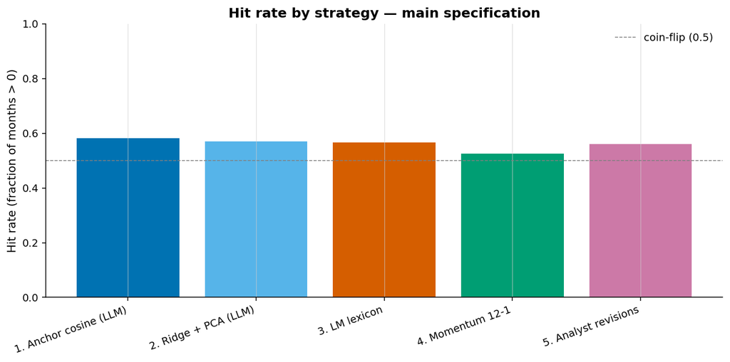

Hit rate by strategy — main specification.

### 4.4 Cumulative long-short return, common window

Ridge + PCA has predictions only from February 2019 onward (it needs a long training window). The chart below restricts every strategy to that common window so endpoints are comparable.

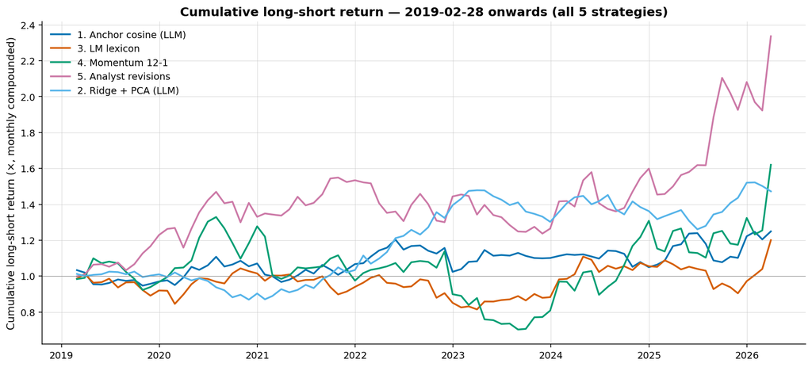

Cumulative long-short return — 2019-02 onwards (all 5 strategies).

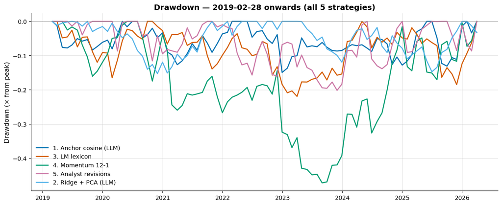

Drawdown — 2019-02 onwards (all 5 strategies).

For a longer-window view of the four signals that do not depend on the ridge model:

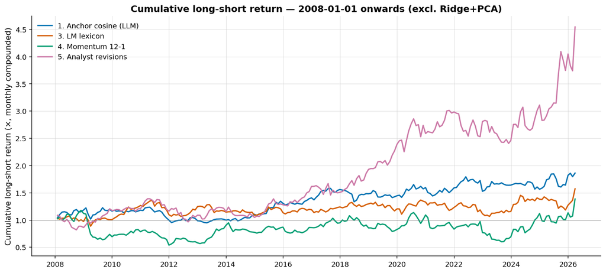

Cumulative long-short return — 2008-01 onwards (excl. Ridge + PCA).

## 5. Robustness

### 5.1 Stale-call exclusion

Sentiment values carry forward unchanged from one earnings call to the next, so a single Δ-sentiment value can drive up to three rebalances before getting refreshed. The **stale-call exclusion** specification drops any ticker with `days_since_earnings > 60` from that month’s cross-section *for the three sentiment strategies only* (anchor, ridge, LM). Momentum and revisions are unaffected — they refresh independently every month — so their rows are identical to the main spec by construction.

If `Sharpe_stale > Sharpe_main`, the carried-forward stale signal was adding noise and the signal is concentrated near the earnings event.

Table 3

|  | Strategy | Ann. return | Ann. vol | Sharpe | Max DD | Hit rate | IR vs. bench | Months |
| --- | --- | --- | --- | --- | --- | --- | --- | --- |
| 0 | 1. Anchor cosine (LLM) | +9.9% | +13.2% | +0.75 | -15.4% | +60.7% | -0.40 | 173 |
| 1 | 2. Ridge + PCA (LLM) | +5.8% | +11.8% | +0.49 | -26.6% | +53.2% | -0.73 | 77 |
| 2 | 3. LM lexicon | +5.5% | +12.5% | +0.44 | -20.9% | +57.8% | -0.60 | 173 |
| 3 | 4. Momentum 12-1 | +4.5% | +26.6% | +0.17 | -61.7% | +52.5% | -0.39 | 303 |
| 4 | 5. Analyst revisions | +9.9% | +16.3% | +0.61 | -30.6% | +56.0% | -0.44 | 248 |

### 5.2 Post-2018 subsample

Table 4

|  | Strategy | Ann. return | Ann. vol | Sharpe | Max DD | Hit rate | IR vs. bench | Months |
| --- | --- | --- | --- | --- | --- | --- | --- | --- |
| 0 | 1. Anchor cosine (LLM) | +3.8% | +11.7% | +0.32 | -14.9% | +58.0% | -0.88 | 88 |
| 1 | 2. Ridge + PCA (LLM) | +5.9% | +10.3% | +0.58 | -15.3% | +57.0% | -0.73 | 86 |
| 2 | 3. LM lexicon | +3.8% | +14.3% | +0.26 | -21.9% | +53.4% | -0.90 | 88 |
| 3 | 4. Momentum 12-1 | +9.0% | +25.6% | +0.35 | -47.2% | +58.0% | -0.49 | 88 |
| 4 | 5. Analyst revisions | +14.0% | +19.0% | +0.74 | -20.2% | +58.0% | -0.45 | 88 |

### 5.3 Rolling 12-month IC

Twelve-month trailing mean of the monthly Spearman IC. Each strategy’s line begins when it accumulates enough months of IC observations.

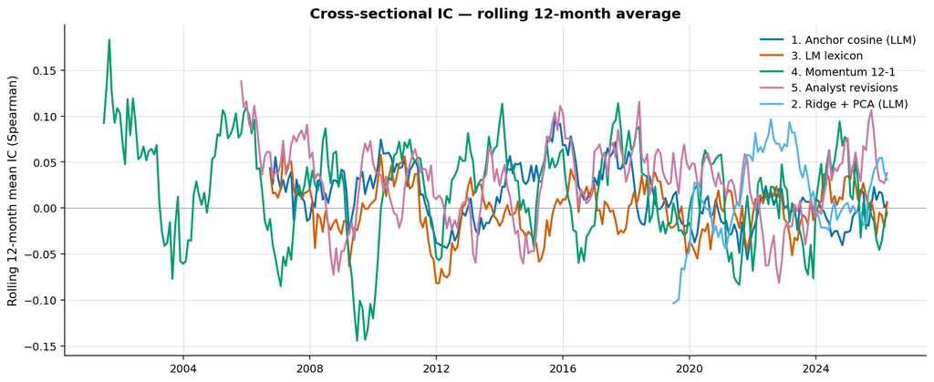

Cross-sectional IC — rolling 12-month average.

### 5.4 Fama-MacBeth joint regression

Performance tables show each signal *in isolation*. The cleaner question is whether each one contributes information **after controlling for the other four**. That is what Fama-MacBeth answers.

**The regression, in one line.** Let $z^k_{i,m}$ denote the monthly cross-sectional z-score of signal $k$ for ticker $i$ at month-end $m$, where $k \in \{a, r, l, p, v\}$ — anchor cosine, ridge prediction, LM lexicon, price momentum, analyst revisions. At each rebalance month $m$ we run a cross-sectional OLS of the 21-day forward return on all five z-scored signals simultaneously:

$$r_{i,m} = \alpha_m + \beta^m_a z^a_{i,m} + \beta^m_r z^r_{i,m} + \beta^m_l z^l_{i,m} + \beta^m_p z^p_{i,m} + \beta^m_v z^v_{i,m} + \varepsilon_{i,m}$$

Z-scoring within each month is what makes the $\beta$’s comparable across signals: a $\beta$ of $+0.002$ means “a +1σ-of-this-signal move is associated with +20 bps of forward 21-day return, holding the other four signals constant”.

We then take the **time-series average** of each month’s coefficient: $\bar\beta_k = \tfrac{1}{T}\sum_m \beta^m_k$. Standard errors on $\bar\beta_k$ are **Newey-West HAC at lag 6**, which corrects for serial correlation in the monthly $\beta^m_k$ sequence. Lag 6 is the standard choice for monthly cross-sectional FM with autocorrelated coefficients; with 21-day-holding returns there is also mechanical overlap that NW handles.

A signal is **dropped from the joint regression** if its average cross-sectional coverage is below 20 tickers per month — otherwise a thin column would force the joint `dropna` to wipe out most rows of the panel.

```
Months: 87   mean R²: 0.1261   α: +0.0194   α t-stat: +4.20
```

Table 5

|  | Signal | β | NW SE | NW t |
| --- | --- | --- | --- | --- |
| 0 | Anchor cosine (LLM) | -0.0001 | 0.0010 | -0.15 |
| 1 | Ridge + PCA (LLM) | +0.0020 | 0.0013 | +1.49 |
| 2 | LM lexicon | +0.0006 | 0.0012 | +0.53 |
| 3 | Momentum 12-1 | +0.0052 | 0.0031 | +1.71 |
| 4 | Analyst revisions | +0.0015 | 0.0016 | +0.93 |

**How to read this.** This is the strict *marginal* test: after the other four signals are in the regression, does this one still load? With monthly cross-sectional z-scoring, a coefficient is significant at the 5 % level when |t| > ~2. The joint $R^2$ above is the time-series average of the monthly cross-sectional $R^2$ — a low number is expected for one-month-ahead stock returns even on a five-signal regression. The intercept $\alpha$ is the average cross-sectional mean return that none of the five signals explains; a positive $\alpha$ with a high t-stat is simply the universe drifting up over the sample.

## 6. Limitations

- **Survivorship bias.** The 100-ticker universe is drawn from current Nasdaq-100 membership. Names that delisted or fell out of the index are excluded by construction. Bias should largely (but not perfectly) cancel in the *relative* comparison; differential effects across signals are possible and untested.
- **Small universe and short OOS.** 100 tickers, quintile legs (16–20 names typically), and a ridge test window of ~7 years (2019–2025) all limit statistical power. A claim like “Sharpe of A is twice B’s” is much weaker on 100 names than on the Russell 3000.
- **No transaction costs.** Defensible as a comparative test (turnover is similar across strategies on a monthly cadence) but not as a deployable-strategy claim.
- **Single embedding model.** Only `text-embedding-3-small` is tested. FinBERT, larger OpenAI embedders, or sentence-transformers fine-tuned on financial text are not compared.
- **Anchor sentences unvalidated.** Different anchors yield different scores; no sensitivity sweep on the choice of the five-on-five anchor set.
- **Embedding-model look-ahead.** The embedding model itself has seen text from the test period during pre-training (the Glasserman-Lin concern). The embedding-as-a-feature setup is more robust to this than a direct LLM-generates-forecast setup, but the bias is still present.
- **Full transcript only.** We do not split prepared remarks from Q&A. A Q&A-only specification is listed as future work.

## 7. Consulted works

The following work informed the methodology, framing, or comparisons drawn in this write-up. Not formally cited inline.

- Ao, Y. and Zhao, Q. (2025). *Familiar signal, new context: The evolution of earnings call sentiment analysis from lexicons to LLMs.* S&P Global Market Intelligence whitepaper. The closest methodological comparison: fine-tuned LLM on Russell 3000.
- Ghosal, D. (2026). *LLM-Driven Investment Models: Evidence from Earnings Call Transcripts.* Sentence-transformer embeddings to forecast one-month forward returns; provided the section-layout template for this write-up.
- Loughran, T. and McDonald, B. (2011). *When Is a Liability Not a Liability? Textual Analysis, Dictionaries, and 10-Ks.* Journal of Finance, 66(1). Source of the LM positive/negative word lists used as the lexicon baseline.
- Tetlock, P. C. (2007). *Giving Content to Investor Sentiment: The Role of Media in the Stock Market.* Journal of Finance, 62(3). Foundational evidence that disclosure language carries return-relevant information.
- Glasserman, P. and Lin, C. (2023). *Assessing Look-Ahead Bias in Stock Return Predictions Generated by GPT Sentiment Analysis.* Cautions about the embedding model itself having seen test-period data during pre-training.
- Jegadeesh, N. and Titman, S. (1993). *Returns to Buying Winners and Selling Losers: Implications for Stock Market Efficiency.* Journal of Finance, 48(1). Source of the price-momentum factor used as Strategy 4.
- Fama, E. F. and MacBeth, J. D. (1973). *Risk, Return, and Equilibrium: Empirical Tests.* Journal of Political Economy, 81(3). Methodology for Section 5.4.
- Newey, W. K. and West, K. D. (1987). *A Simple, Positive Semi-Definite, Heteroskedasticity and Autocorrelation Consistent Covariance Matrix.* Econometrica, 55(3). HAC standard errors used in Section 5.4.